# Statistical inference with the GSS data

## Setup

### Load packages

```r
library(ggplot2)
library(dplyr)
library(statsr)
```

### Load data

```r
load("gss.Rdata")
dim(gss)
```

```
## [1] 57061   114
```

As can be seen above, the dataset consisted of over 57,000 observations with 114 possible variables. Further data processing selected variables of interest and handled missing data elements.

## Part 1: Data

## Background of the GSS

The GSS gathers data on contemporary American society in order to monitor and explain trends and constants in attitudes, behaviors, and attributes. Hundreds of trends have been tracked since 1972. In addition, since the GSS adopted questions from earlier surveys, trends can be followed for up to 70 years.

The GSS contains a standard core of demographic, behavioral, and attitudinal questions, plus topics of special interest. Among the topics covered are civil liberties, crime and violence, intergroup tolerance, morality, national spending priorities, psychological well-being, social mobility, and stress and traumatic events.

Altogether the GSS is the single best source for sociological and attitudinal trend data covering the United States. It allows researchers to examine the structure and functioning of society in general as well as the role played by relevant subgroups and to compare the United States to other nations.

The GSS is conducted as an in-person interview by the team at National Opinion Research Center (NORC) - hosted at the University of Chicago - and targets adults living in the United States. The GSS sample is drawn using an area probability design that randomly selects respondents in households across the United States to take part in the survey. Respondents that become part of the GSS sample are from a mix of urban, suburban, and rural geographic areas. Participation in the study is strictly voluntary.

The GSS is, however, an observational study - with no explicit random assignments to treatments - so all relationships indicated may indication association, but not causation.

As it relates to bias, there are a few potential concerns:

First, the changes in methodologies over the years may introduce bias. As an example, it was not until 2006 that Spanish-speaking adults were included in the survey.

By using a voluntary in-person survey that takes approximately one hour, there is the possibility of underreporting those that choose to not respond to the survey.

Since the answers to the interview questions are not validated, respondents may alter their responses in a variety of ways, such as expressing desireable behaviours and traits, while under-reporting undesirable ones.

## Part 3: Exploratory data analysis

```r
##Let’s start by selecting the variables of interest from the dataset then removing NA values


sciVSparty <- gss %>% select(consci,partyid) %>% filter(!is.na(consci), !is.na(partyid))
##Then summarizng the two variables in a frequency table
table(sciVSparty$partyid,sciVSparty$consci)
```

```
##
##                      A Great Deal Only Some Hardly Any
##   Strong Democrat            2254      2850        523
##   Not Str Democrat           3296      3937        556
##   Ind,Near Dem               2051      2161        279
##   Independent                1842      2609        467
##   Ind,Near Rep               1510      1547        178
##   Not Str Republican         2580      2792        332
##   Strong Republican          1551      1546        224
##   Other Party                 210       266         40
```

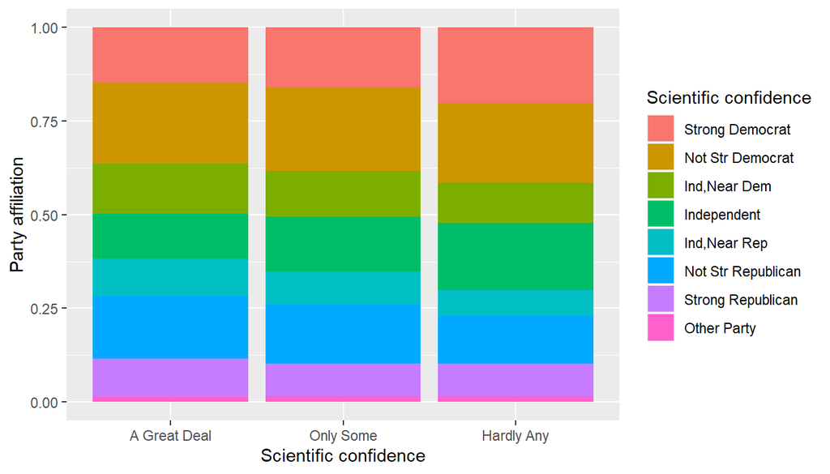

```r
##We use a segmented barplot to visualize our results.
ggplot(sciVSparty, aes(x =consci, fill = partyid)) + geom_bar(position = "fill") + scale_fill_discrete(name = "Scientific confidence") + xlab("Scientific confidence") + ylab("Party affiliation")
```

## Part 4: Inference

Let’s use chi-square independence test to evaluate the relationship between this two categorical variables.

Hypotheses

H0 (nothing going on): party affiliation and confidence in the scientific community are independent.

HA (something going on): party affiliation and confidence in the scientific community are dependent.

Firt we have to make contigency table to pass it to chi-square test function.

```r
table <- table(sciVSparty$partyid, sciVSparty$consci)
chisq.test(table)
```

```
##
##  Pearson's Chi-squared test
##
## data:  table
## X-squared = 211.93, df = 14, p-value < 2.2e-16
```

Here we see that the p-value is very small compared to our signifcant level so we will reject our null hypothesis in favor to our alternative. Thus,there is a significant relationship between party affiliation and confidence in the scientific community.